# Plotting Gene Mutation Counts

Childhood Cancer Data Lab, Alex’s Lemonade Stand Foundation

## Introduction

At the Data Lab, we really like using notebook documents like [Rmarkdown](https://rmarkdown.rstudio.com) (this document) and [Jupyter](https://jupyter.org) for development and data exploration. Notebooks allow you to combine text, code, and results in a single document that is easy to work with interactively. Using notebooks allows much more freedom to include a lot of explanatory text, much like code comments, but with simpler syntax and the ability to include formatting and links more easily through the use of [markdown-formatted text](https://rmarkdown.rstudio.com/lesson-8.html) (or using the [new visual editor in RStudio](https://www.rstudio.com/blog/exploring-rstudio-visual-markdown-editor/)).

When you are ready to share your results with others, notebooks like this can easily be converted into a document such as `.html` (web page) or `.docx` (MS Word), results, plots, and all.

**A note on formatting:** We like to keep our documents formatted with the philosophy of one sentence per line. This approach interacts well with git and GitHub, which record edits based on the line that changed. So keeping each sentence on a separate line makes it easier to see what has changed when editing a large block of text; if we just put spaces between sentences within a paragraph, they would appear to git as a single line, and a change anywhere would look like a change to the whole paragraph. To separate paragraphs in markdown, we have to use a blank line, so separating sentences onto their own lines won’t affect the final output.

This notebook is an example of an analysis that might be performed using the output of the `01_count-gene-mutations.R` script (though with a lot of meta-commentary about the steps and choices made along the way). We are assuming that counting was performed for the low-grade astrocytoma (LGAT) and medulloblastoma MAF files for this notebook. If you would like, you can make a copy of this notebook, change the input files (and probably some text), and apply the same analysis to different data sets!

## Setup

### Load packages

Loading the packages you plan to use frequently first is usually good practice. However, we don’t always have to load all of the packages we plan to use. In the code below, you will sometimes see that we use functions with the form `package::function()`. This `::` notation tells R to use the function from a particular package, whether it has been loaded with `library()` or not. This can be more efficient if you are only using a single function from a package, and it has the additional benefit of providing extra context about which package provided a particular function, which can be easy to lose track of if many packages are loaded, or when using an unfamiliar package.

```r
library(dplyr) # data wrangling tools
library(ggplot2) # the plotting package we will use
```

### Specify files and paths

We like to specify all our input and output paths toward the top of the notebook, making them easy to find and update as needed. During development, we might not know exactly what files are needed at the start, so this may not get *written* first, but having a consistent and prominent place where all paths are defined makes it easy to quickly determine what files are needed and where they will be found.

Since this is an `Rmarkdown` file, all of the file paths will be relative to the location of this file. This means that if the `Rmarkdown` file moves, the relative paths to files we are interacting with would change, which can be annoying and confusing! A nice solution to help manage paths we can use is the [`here` package](https://here.r-lib.org), which will allow us to specify paths relative to the project root directory. The project root is found by looking for an R project file with the `.Rproj` extension in a parent directory from the file (or a `.git` directory if there is no project file).

We will also take advantage of the fact that the `file.path()` function (and the `here::here()` function), allows us to specify paths as a series of comma-separated partial paths, i.e., individual directories and files. If we knew everyone were using a UNIX machine, we could use a path like `analysis/gene_counts`, but this syntax is a bit less portable to other systems. (Thankfully, paths like this *do* work on Windows now!) Using the separated list of elements also makes it easier to join partial paths together. We won’t have to worry about whether a partial path ends with a separator slash (`/`) or not; `file.path()` will add it as needed!

```r
# Set the directory where the counts files are found
counts_dir <- here::here("analyses", "mutation_counts")

# File paths to the counts files for LGAT and medulloblastoma
lgat_path <- file.path(counts_dir, "LGAT_gene-mutations.tsv")
mb_path <- file.path(counts_dir, "Medulloblastoma_gene-mutations.tsv")

# Reference directory & FLAGS (frequently mutated genes)
ref_dir <- here::here("data", "reference")
flags_path <- file.path(ref_dir, "FLAGS.txt")
```

While a rendered version of this notebook complete with plots will be saved in the same location as this file, it can be useful to have a separate location for “presentation-ready” plots. You might have that as a subfolder of the analysis folder, or, as we do here, a separate `plots` location that might be used for multiple analyses. We still want to keep that separate location organized, so we will make a subfolder to hold the output from this particular analysis.

```r
# set the directory to save output plots
plots_dir <- here::here("plots", "mutation_counts")

# create the plots directory if it does not exist
if (!dir.exists(plots_dir)){
  dir.create(plots_dir, recursive = TRUE)
}
```

### Define functions

In this section we define any functions that we will use later in the script. While we could define functions later, it is nice to have them grouped together near the top of the notebook for at least a few reasons: - The first is that we will always know where to look for function definitions. Patterns and conventions make it easier for us to know what to expect when we come back to a file after a while away and may need to make changes - Another reason is that if the function definitions are at the top, we can use them anywhere below, without worrying about invoking a function before it is defined. Finally, having the functions grouped together will make it easier if we decide to move them to an external file: - If the set of functions gets large, or if we want to use some functions across multiple notebooks, we can create a separate `.R` file (or files) and then use the `source()` command to load those functions into this notebook (or others) all at once.

In this case, we will only have one function, which will make a plot of the number of samples with mutations for each gene. We’ll give it some options to allow filtering to a minimum number of mutated samples and highlighting particular genes of interest.

Importantly, we will be sure to include some comments with documentation of the arguments for the function, as well as a description of what the function will return.

To make these comments a bit more structured, we will use the format from the [`roxygen2`](https://roxygen2.r-lib.org/) package for these comments, which would be useful for automatically generating documentation if we were creating an R package. We aren’t generating separate documentation files here, but it is still a nice enough convention, and RStudio has an option in the `Code` menu called `Insert Roxygen Skeleton` that can save us a bunch of typing and create the outline of what we need in a single step.

```r
#' Plot the number of  mutations for each gene from a data frame
#'
#' Filters to a cutoff and sorts genes from most to least mutated, then
#' creates a bar plot of the mutation counts, optionally highlighting
#' genes of interest.
#'
#' @param mutations_df A data frame with columns `Hugo_Symbol` and `mutated_samples`
#' @param min_mutated The minimum `mutated_samples` value to include in the plot
#'  (default: 3)
#' @param highlight_genes A vector of genes to highlight in the plot (optional)
#' @param highlight_title The title for the highlighted genes legend
#'  (default: "Gene of interest")
#'
#' @return A ggplot2 plot object
#'
plot_gene_mutations <- function(
  mutations_df,
  min_mutated = 3,
  highlight_genes = c(),
  highlight_title = "Gene of interest"
){
  plot_df <- mutations_df |>
    filter(mutated_samples >= min_mutated) |>
    arrange(desc(mutated_samples)) |>
    # make the gene names a factor, in the order they appear after sorting
    mutate(gene = factor(Hugo_Symbol, levels = Hugo_Symbol))

  if (length(highlight_genes) == 0){
    # If there are no highlight genes, we don't include that in the ggplot aesthetics
    plot_obj <- ggplot(plot_df,
                       aes(x = gene,
                           y = mutated_samples))
  } else {
    # There are highlight genes, so add them to the data frame
    plot_df <- plot_df |>
      mutate(
        # add a column with the highlight status, make it a factor for ordering
        highlight = ifelse(gene %in% highlight_genes, "Yes", "No"),
        highlight = factor(highlight, levels = c("Yes", "No"))
      )
    # create the plot object with colored fill
    plot_obj <- ggplot(plot_df,
                       aes(x = gene,
                           y = mutated_samples,
                           fill = highlight))
  }

  # Add layers and formatting to the plot
  plot_obj <- plot_obj +
    geom_col() +
    labs(x = "Gene symbol",
         y = "Mutated samples",
         fill = highlight_title) +
    theme_bw() +
    theme(axis.text.x = element_text(angle=45,hjust=1)) +
    scale_fill_brewer(palette = "Set1")

  # Return the plot
  return(plot_obj)
}
```

## Gene mutation exploration

Now that we have done all of our setup, we can move on to the bulk of the work.

### Reading data

We’ll first read in the data for the two cancer types that we had defined input paths for in the setup section.

```r
# read in mutation count files for plotting
lgat_df <- readr::read_tsv(lgat_path)
mb_df <- readr::read_tsv(mb_path)
```

We will also read in the table of genes frequently mutated in exons:

```r
flags_df <- readr::read_tsv(flags_path)
```

### Quick stats

Usually at this stage of an analysis we might want to get some quick statistics about the data that we just read in. Here we will calculate and print out the number of genes in each of the tables.

```r
cat("LGAT mutated gene count:", nrow(lgat_df))
```

```
LGAT mutated gene count: 631
```

```r
cat("\n") # print return between
```

```r
cat("Medulloblastoma mutated gene count: ", nrow(mb_df))
```

```
Medulloblastoma mutated gene count:  1254
```

**A note on code chunk names:** You might have noticed that in most of the previous code chunks, I included some text in the `{r}` brackets on the first line of the chunk, which serves as the name of the chunk. The use of these names is a bit controversial among members of the Data Lab. Some of us like them for the clarity and the fact that they allow easy navigation in RStudio. Others find that they get out of sync with the code inside them and can be more trouble than they are worth. In particular, no two chunks can have the same name, so sometimes duplicating or splitting a chunk can accidentally create a notebook that won’t render properly. Here we are using names for chunks with defined purpose, but not for the more exploratory, iterative chunks in this section and the next, but your preferred method is up to you!

### Make plots

We’ll start by using the most basic version of the plotting function we defined earlier, with no highlighting, using the LGAT data:

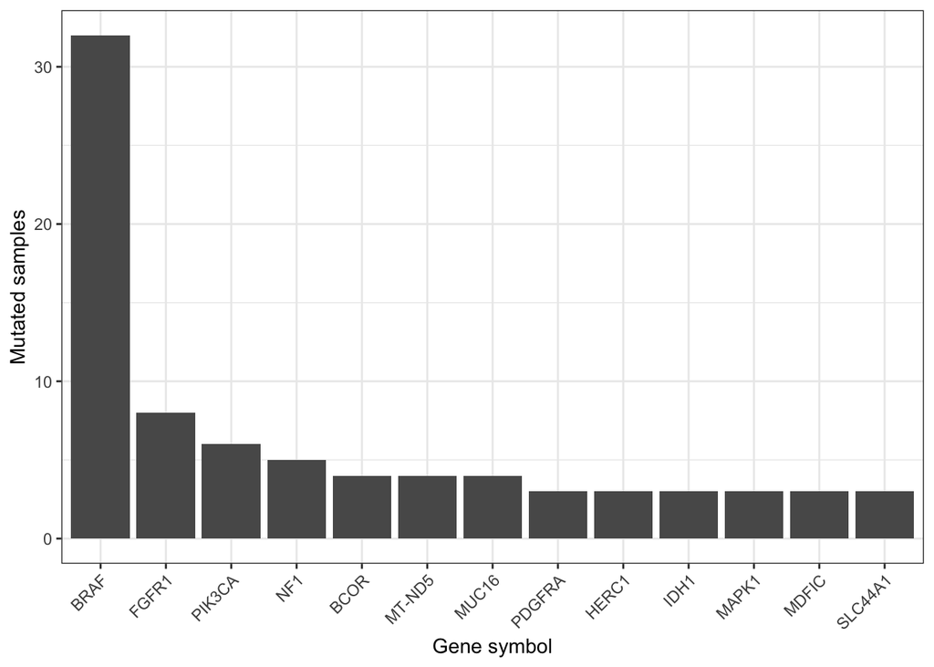

```r
plot_gene_mutations(lgat_df)
```

We do want to make sure we highlight any frequently mutated genes, so let’s add that argument, highlighting the genes from the FLAGS data set (stored in `flags_df`):

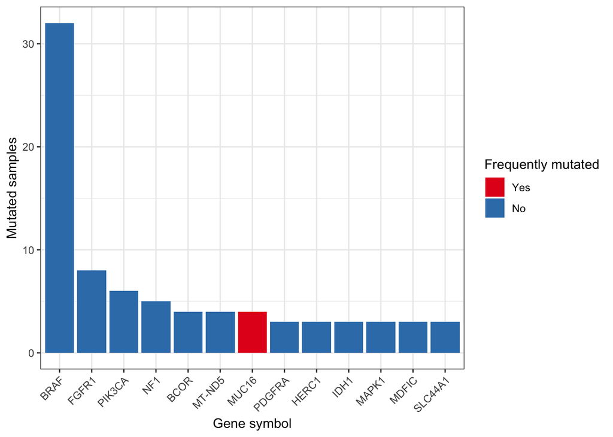

```r
plot_gene_mutations(lgat_df,
                    highlight_genes = flags_df$gene,
                    highlight_title = "Frequently mutated")
```

If we want, we can save the plot object we made into its own variable, and since it is a ggplot object, we can also add additional content or formatting that the function might not have supported.

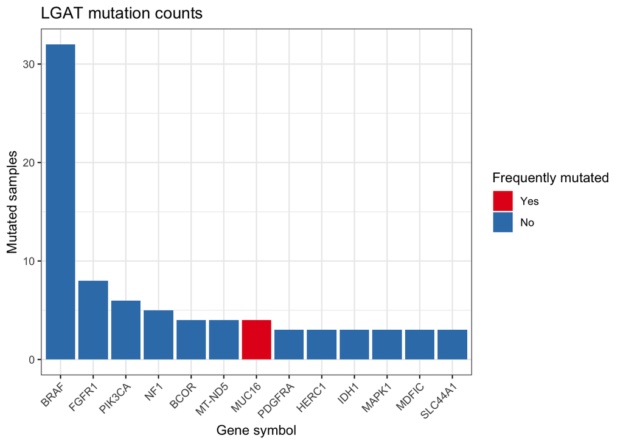

```r
lgat_plot <- plot_gene_mutations(lgat_df,
                                 highlight_genes = flags_df$gene,
                                 highlight_title = "Frequently mutated")

# add a title to the plot
lgat_plot <- lgat_plot + labs(title = "LGAT mutation counts")

# view the plot
lgat_plot
```

Now let’s repeat that for the medulloblastoma data.

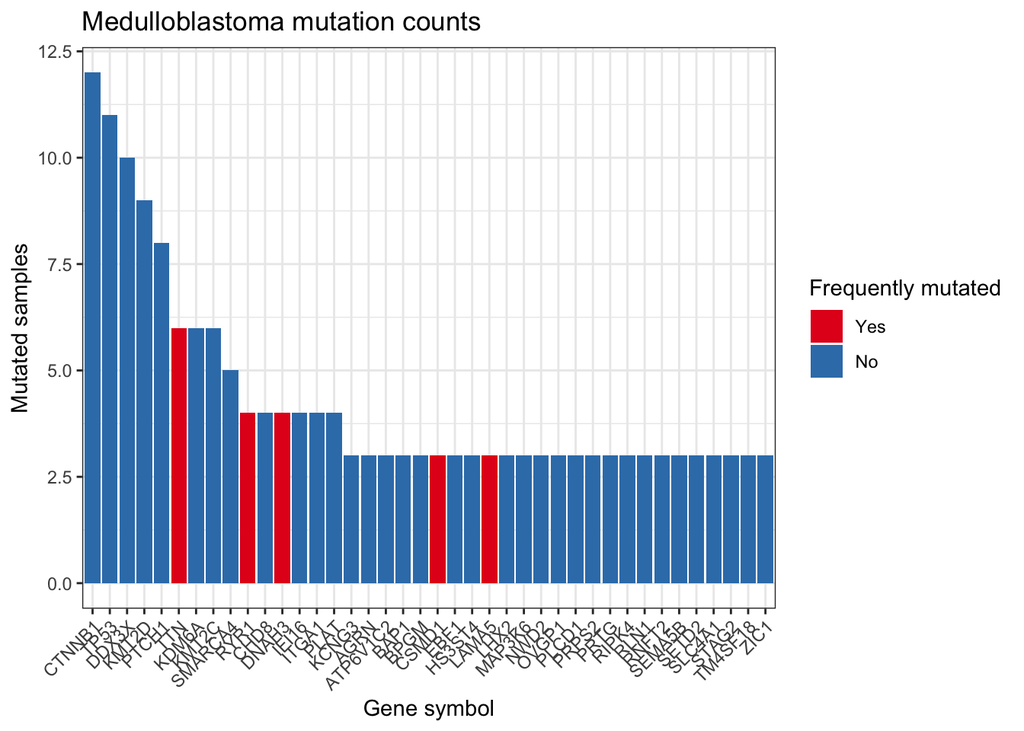

```r
mb_plot <- plot_gene_mutations(mb_df,
                               highlight_genes = flags_df$gene,
                               highlight_title = "Frequently mutated")

# add a title to the plot
mb_plot <- mb_plot + labs(title = "Medulloblastoma mutation counts")

# view the plot
mb_plot
```

That plot seems to be a bit cluttered, so we will make the x axis labels a bit smaller:

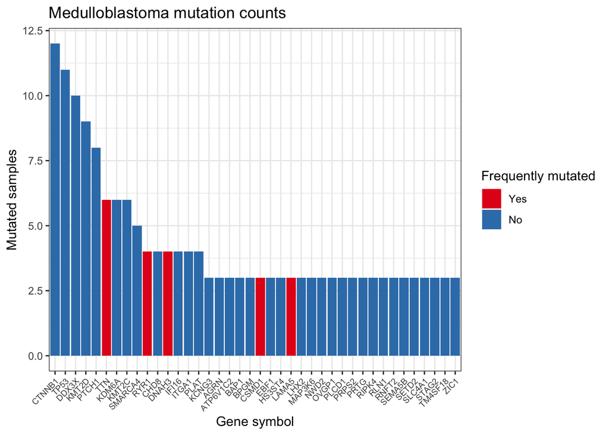

```r
mb_plot <- mb_plot + theme(axis.text.x = element_text(size = 7))

mb_plot
```

### Saving plots

If we are happy with the plots, we can save them. We do want to be sure to specify the width and height of the saved plots, as that can sometimes change unpredictably depending on the R environment.

We didn’t define the output plot file names at the top, just the directory, so we will create the file names now (using `file.path()` again!).

In most cases, defining outputs here in the notebook will be just fine, but if the output here were likely to be feeding into another analysis, I would probably want to be more careful and define all the outputs at the top of the notebook.

```r
ggsave(
  file.path(plots_dir, "LGAT_mutation-counts.png"),
  lgat_plot,
  width = 7,
  height = 7
)
ggsave(
  file.path(plots_dir, "Medulloblastoma_mutation-counts.png"),
  mb_plot,
  width = 7,
  height = 7
)
```

## Session information

We like to end all of our notebooks with a call to a function that provides a brief report about the versions of R and all packages that were used in the notebook. This can be very useful for debugging down the line, as different versions of packages, R, or even the operating system can sometimes result in slightly or significantly differen outputs.

The most common such function is `sessionInfo()`, which is part of base R and is what we are using here, but a nice alternative is the function `sessioninfo::session_info()` (part of the [`sessioninfo` package](https://sessioninfo.r-lib.org/)), which provides a somewhat more neatly-formatted report with a bit more information.

[session information not shown]